# Exploration of potential parametric forms of conditional extreme value models

2024-10-25

## Set-up

Currently, we work with 19 years of daily maximum temperature data over summer months (June, July, August). (The issue with year 20 remains unresolved.)

## Follow-up from meeting with Simon: exploring $\alpha$ against distance

Recall the plot of marginal estimates of $\alpha$ parameter against distance[m] for the three conditioning sites. This is done using the sequential method (see below).

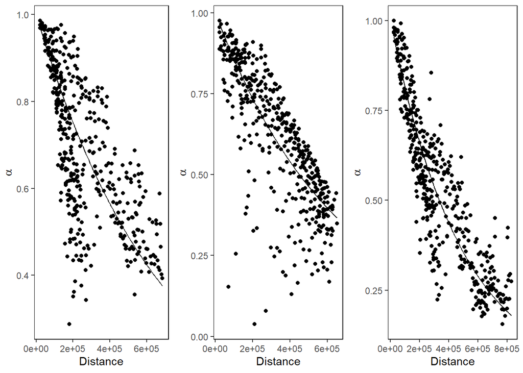

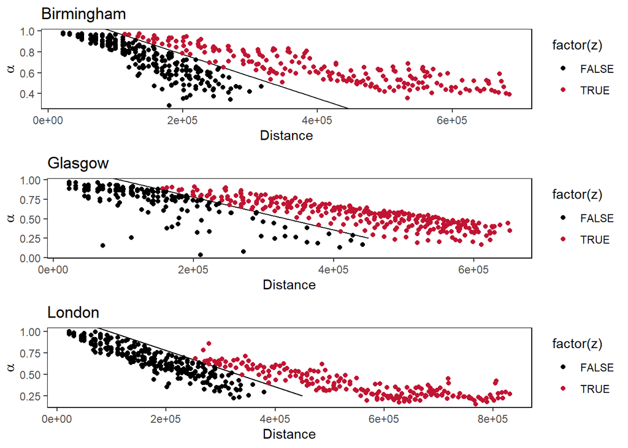

Link both back to spatial locations to explore any potential patterns.

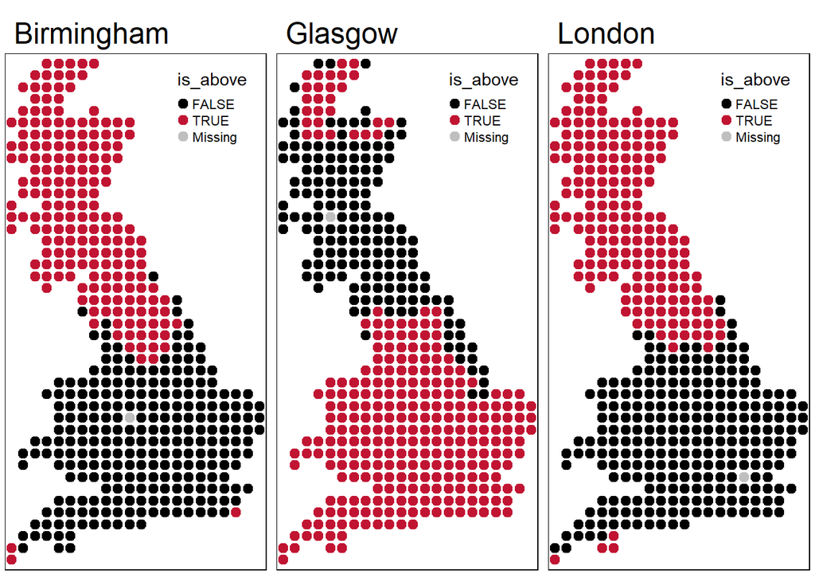

Birmingham and London show a similar pattern, which suggest higher dependence decay with distance (black) in the south of the mainland UK and in the vicinity of the conditioning sites. The dividing line could be moved to explore this result further.

## Sequential parameter estimation

1. Fix $\beta=0$, estimate $\hat{\alpha}$.
2. Fix $\alpha=\hat{\alpha}$, estimate $\hat{\beta}$.
3. Fix $\alpha=\hat{\alpha}$ and $\beta=\hat{\beta}$, estimate $\hat{\mu}$ and $\hat{\sigma}$.
4. Calculate observed residuals, estimate $\hat{\mu}_{AGG}$, $\hat{\sigma}_{AGG}$, $\hat{\delta}_l$ and $\hat{\delta}_u$.

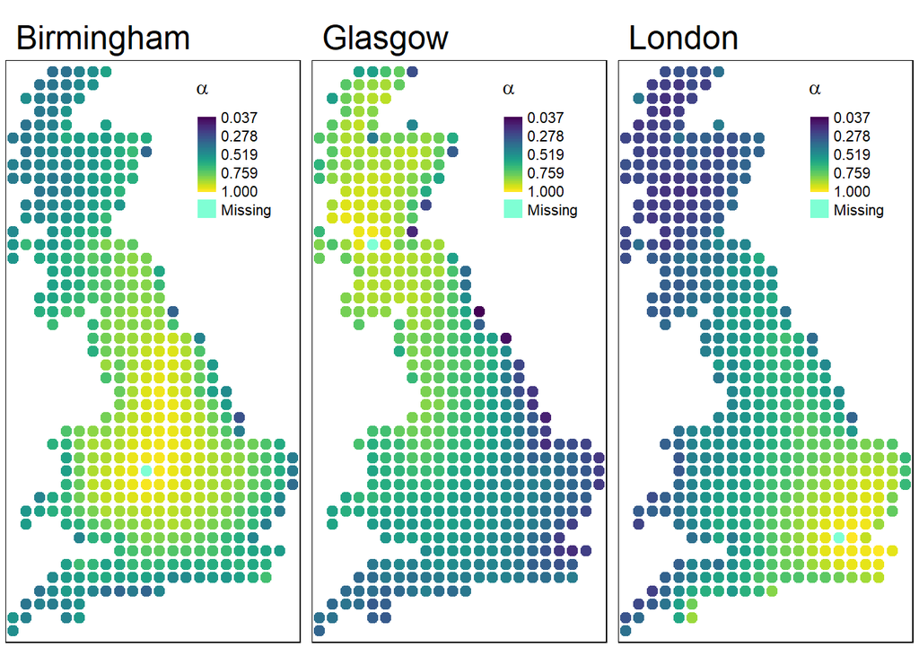

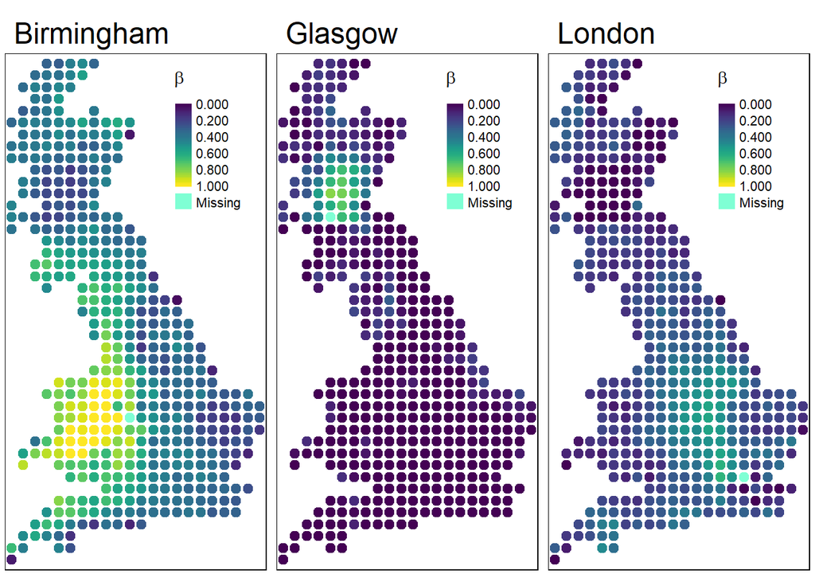

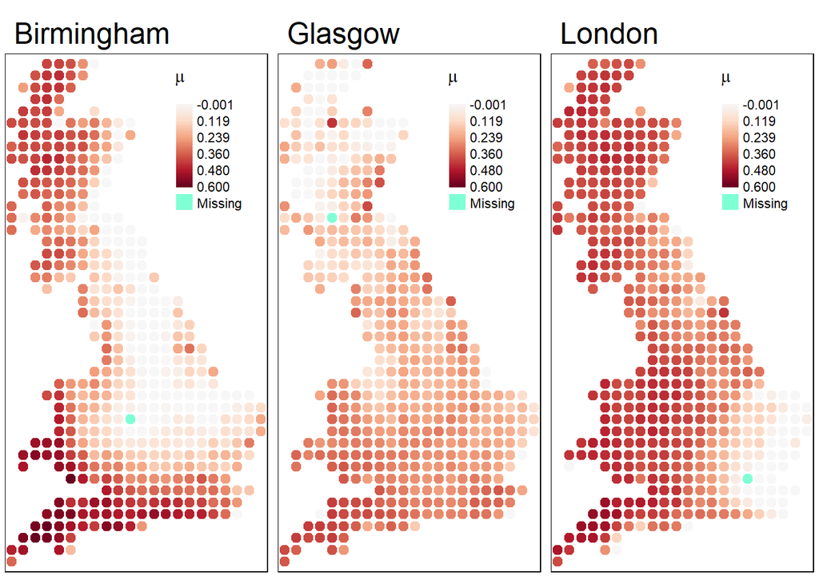

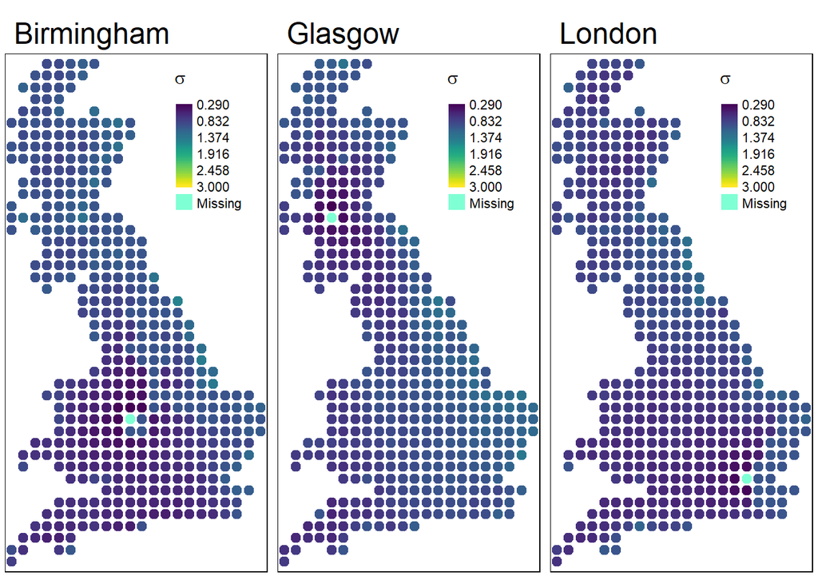

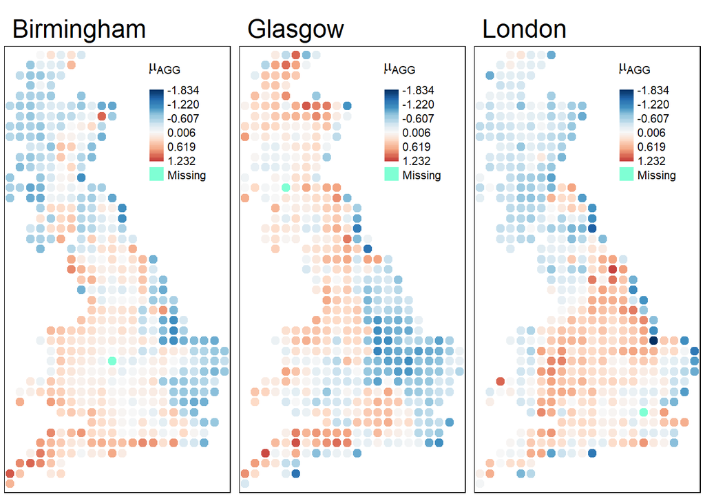

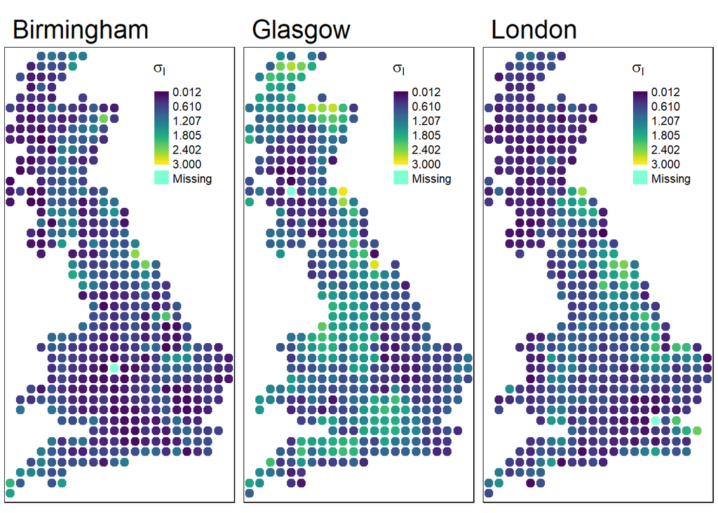

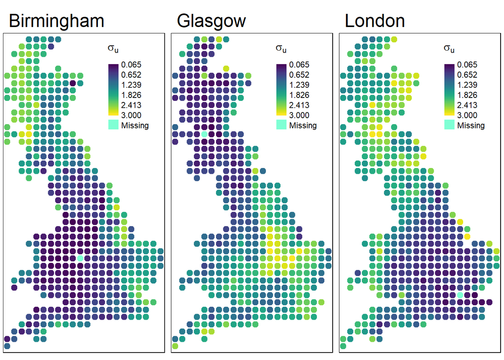

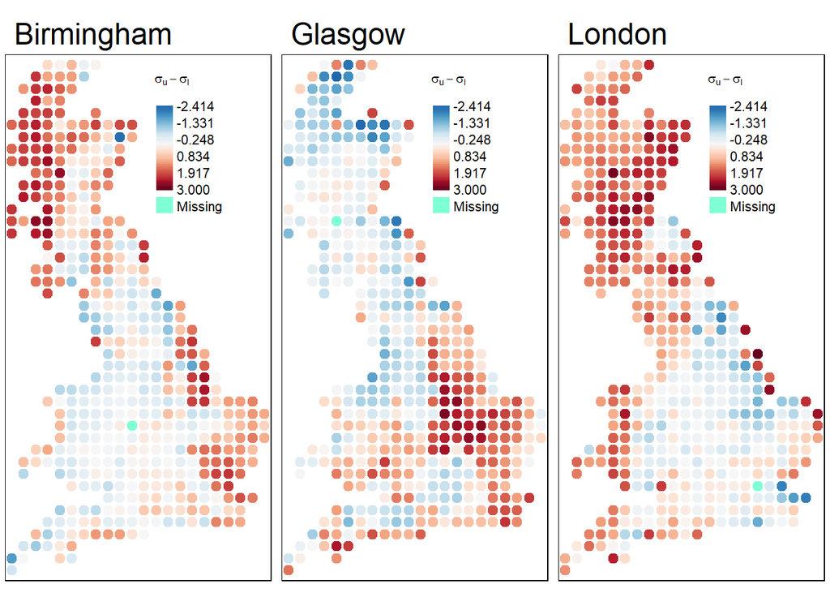

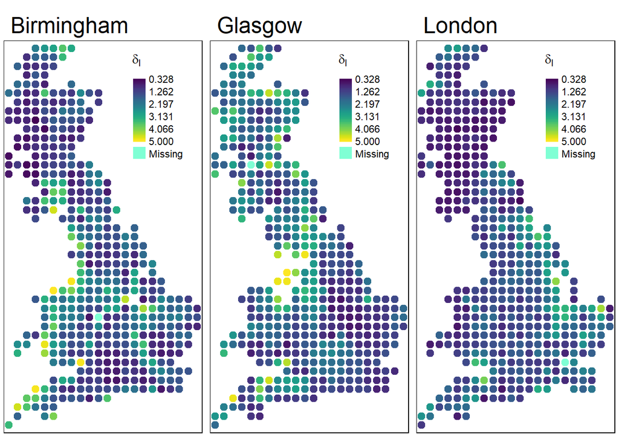

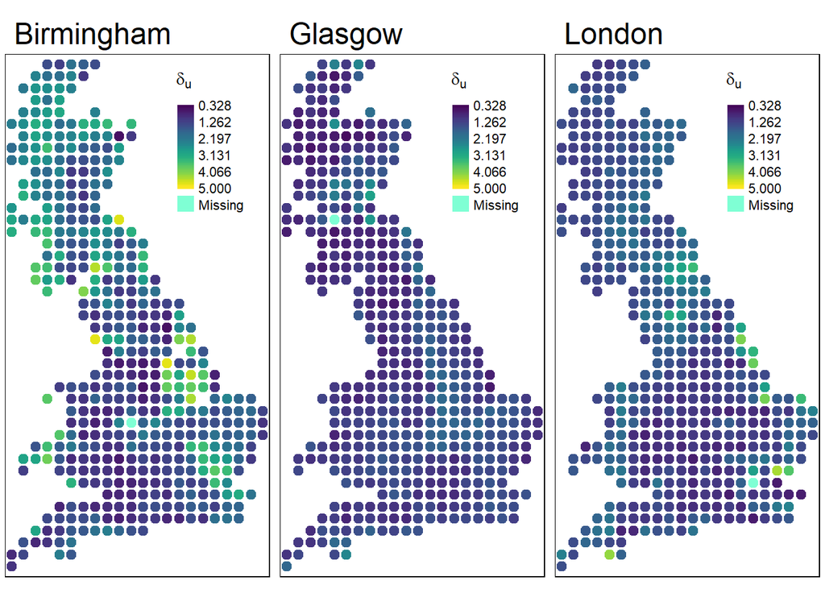

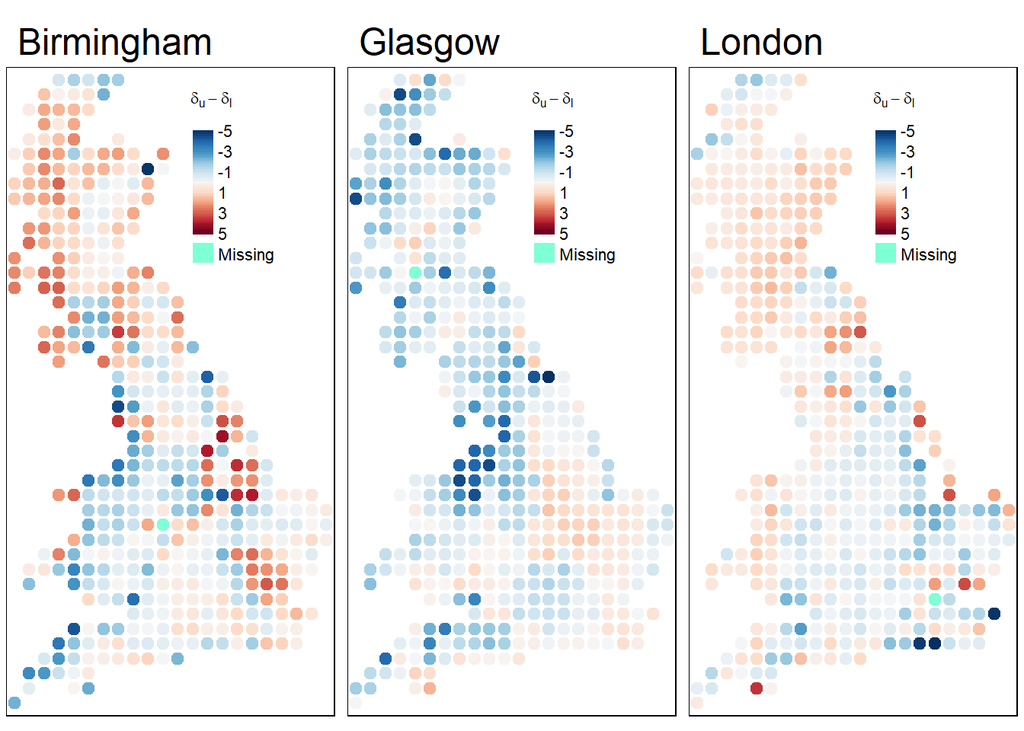

Now, the same approach with alpha values on the fitted exponential curve with distance, so we use estimates of $\hat{\alpha}$ to fit an exponential curve to as a function of distance of site $i$ from the conditioning site $j$.

1. Fix $\alpha=\alpha \left( d_{ij} \right) = \exp \left\{ - \phi d_{ij} \right\}$, estimate $\hat{\beta}$.
2. Fix $\alpha=\alpha \left( d_{ij} \right)$ and $\beta=\hat{\beta}$, estimate $\hat{\mu}$ and $\hat{\sigma}$.
3. Calculate observed residuals, estimate $\hat{\mu}_{AGG}$, $\hat{\sigma}_{AGG}$, $\hat{\delta}_l$ and $\hat{\delta}_u$.

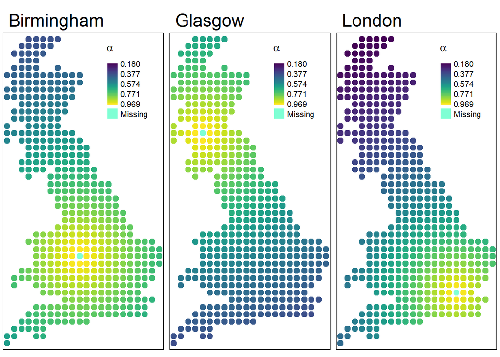

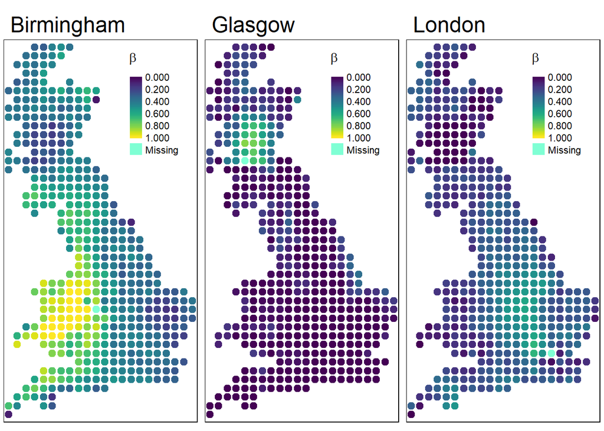

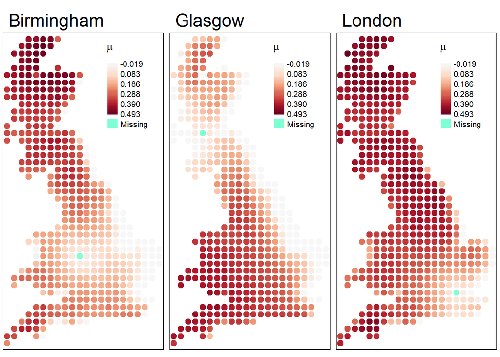

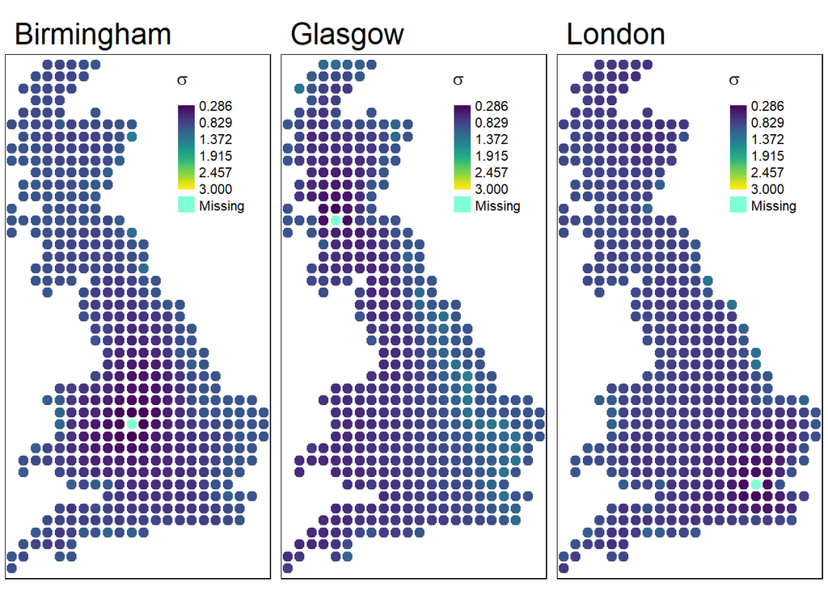

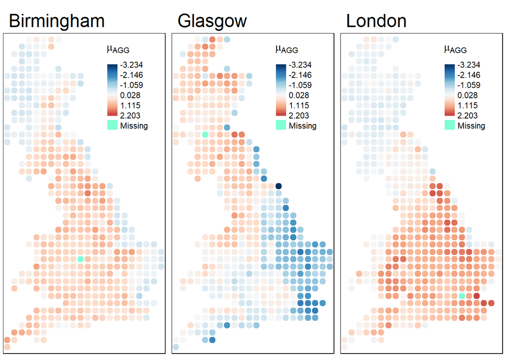

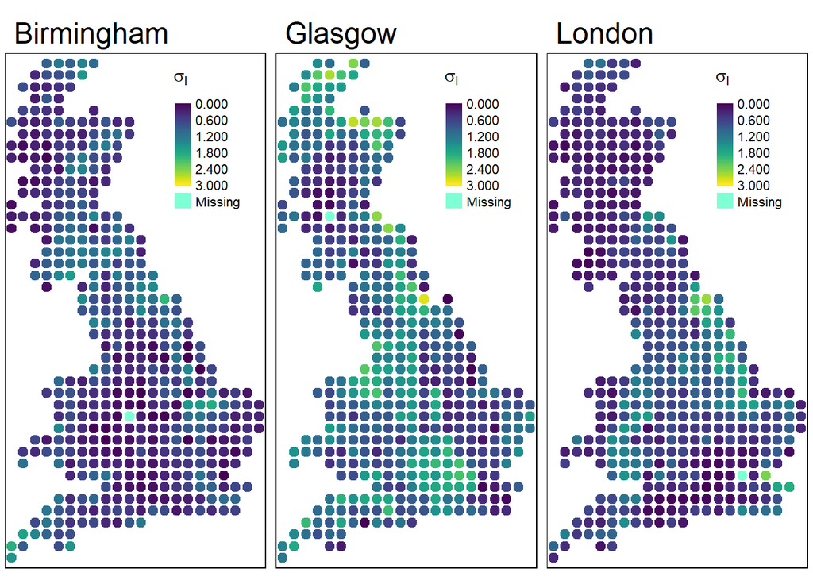

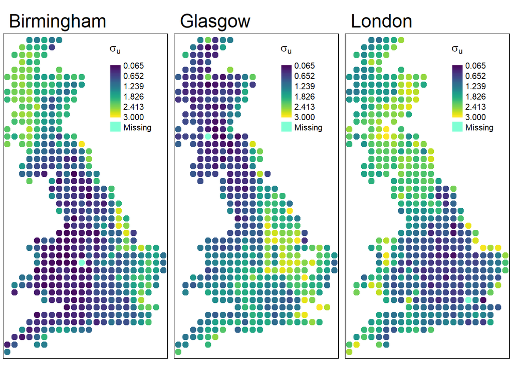

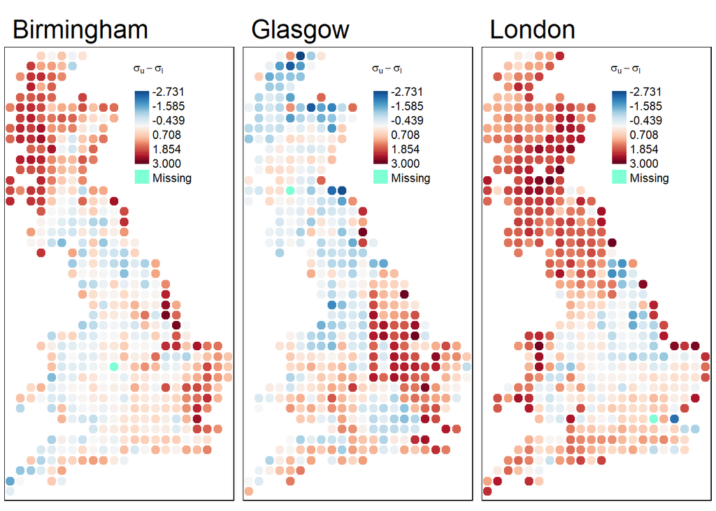

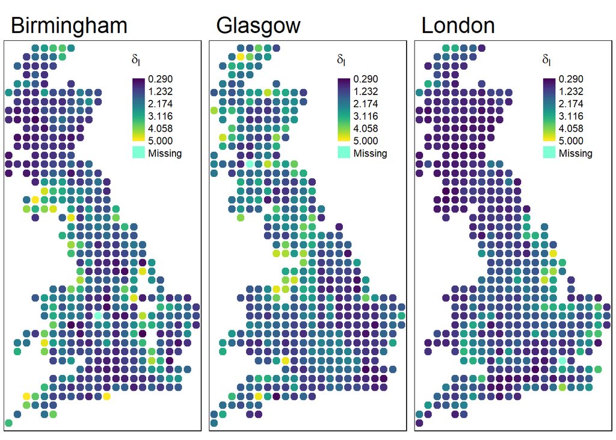

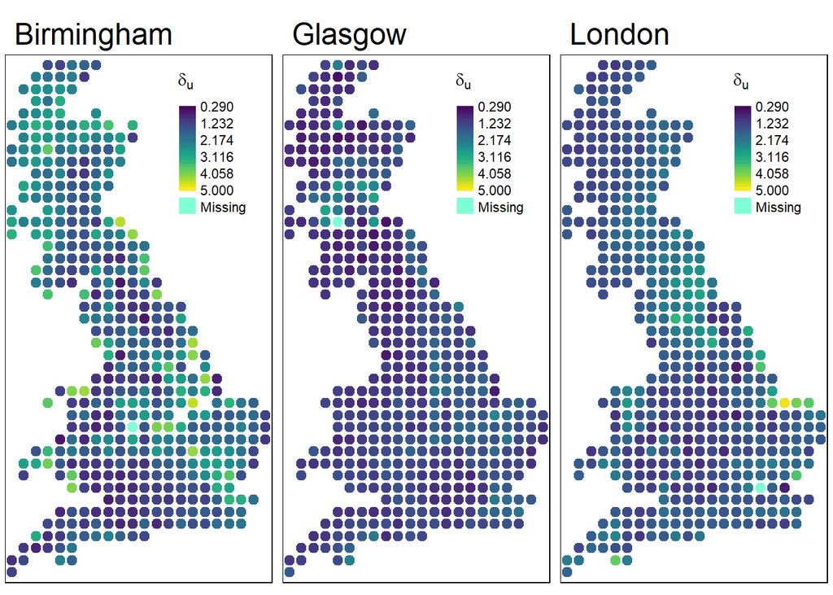

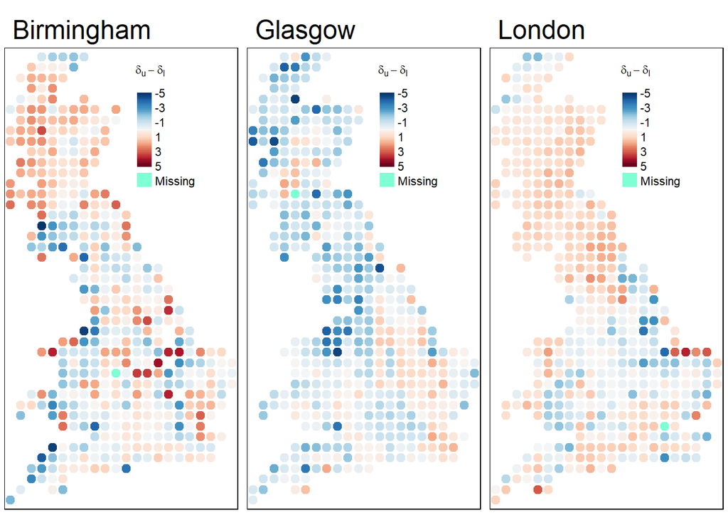

## New iterative approach

First, we plot the iterations of parameter estimates to check convergence.

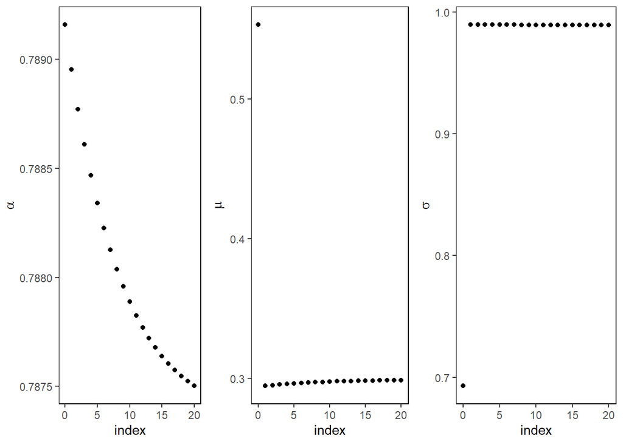

Repeat also for Glasgow.

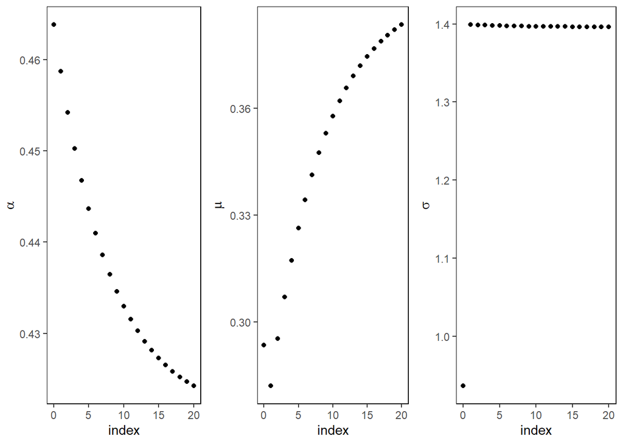

and London.

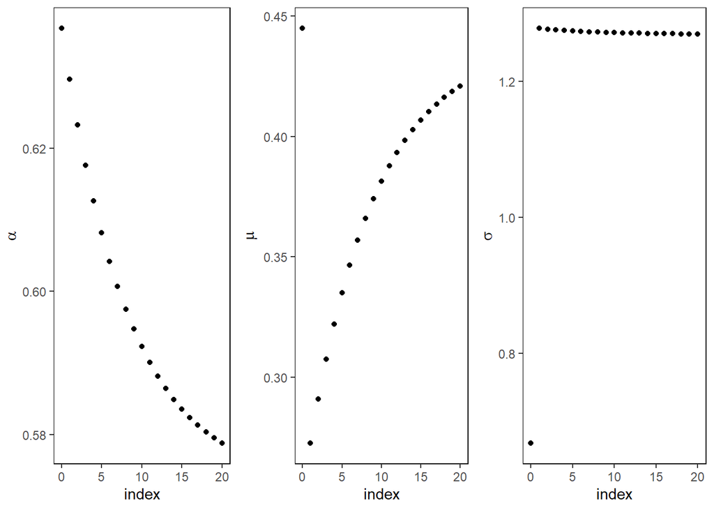

Plot also on a map.

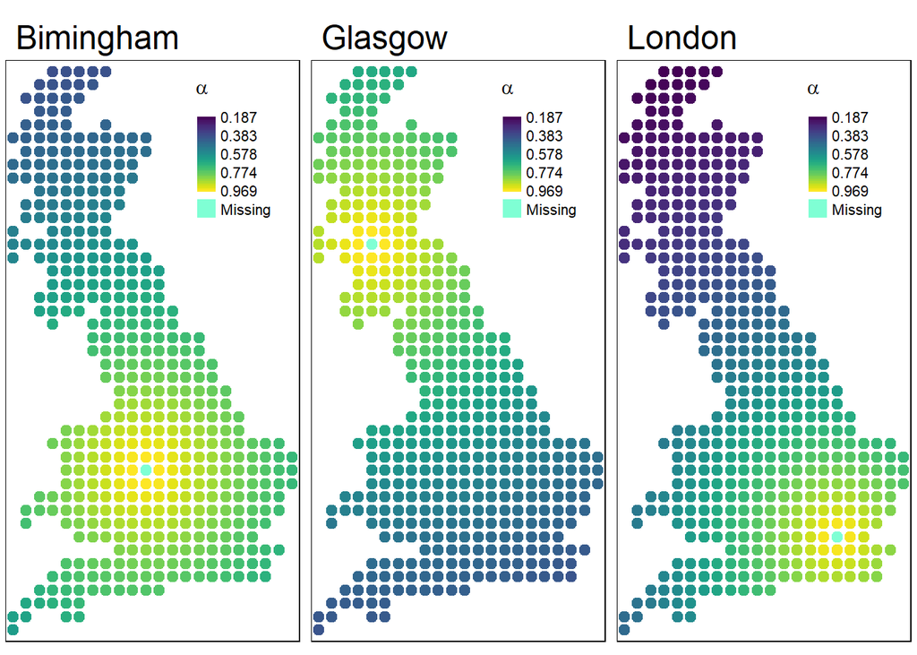

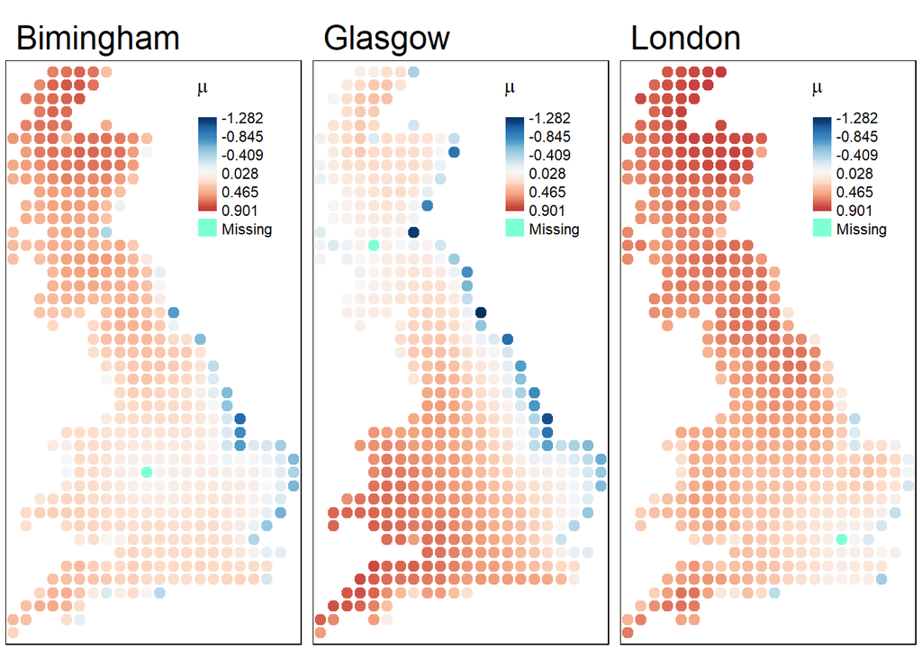

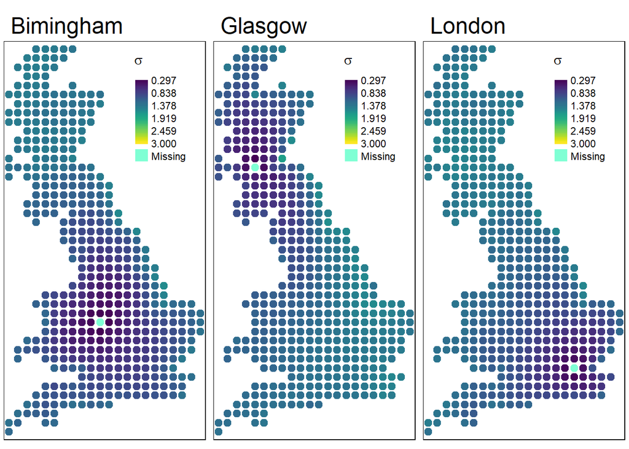

## Conditioning on any random site

Currently, the analysis is conditioning on Birmingham, Glasgow and London, ordered as first 3 columns of the temperature data for an easy link.

One way would be to calculate distance from each of the site and then filter distance for the site needed, which will be faster as this distance matrix will be already saved (twice as $d_{ij}$ and $d_{ji}$ are identical ).